# Models of Interest

Catherine Vanaise

23/03/2021

# Preliminary models testing the hypotheses

```r
#Loading the data
library(gsheet)
mydata <- gsheet2tbl("https://docs.google.com/spreadsheets/d/1zcYomqhibeLyxaeTyJz8etOqUWqDLH_4/edit#gid=550557869")
```

```r
mydata$primEducGdp <- mydata$primEduc/mydata$gdp*100
mydata$lowSecEducGdp <- mydata$lowSecEduc/mydata$gdp*100
mydata$upSecEducGdp <- mydata$upSecEduc/mydata$gdp*100
mydata$longCycleTerEducGdp <- mydata$longCycleTerEduc/mydata$gdp*100
```

```r
if (!require("plm")) install.packages("plm")
library(plm)
```

We must first determine if we need a fixed-effects model to help remove the effects of time-invariant characteristics (such as the countries and years). If fixed-effects do affect the model, it is important to control for them to ensure that the model will then be truly measuring the impact of the independent variables on the dependent variable.

Considering the results of the Hausman test for all models that show a p-value lower than 0.05, we need a fixed-effects model. EXCEPT: Model with long cycle tertiary education with income dummy (should use random) (other models with income suggest using random, but we do not study them here)

## Model with control variables only

```r
modelControlF <- plm(unemployment ~  avRatio + adultEducTer,
             data = mydata, index = c("country", "year"), model = "within")
modelControlR <- plm(unemployment ~ avRatio + adultEducTer,
             data = mydata, index = c("country", "year"), model = "random")
phtest(modelControlF, modelControlR)
```

```
##
##  Hausman Test
##
## data:  unemployment ~ avRatio + adultEducTer
## chisq = 11.527, df = 2, p-value = 0.003141
## alternative hypothesis: one model is inconsistent
```

```r
#need fixed
summary(modelControlF)
```

```
## Oneway (individual) effect Within Model
##
## Call:
## plm(formula = unemployment ~ avRatio + adultEducTer, data = mydata,
##     model = "within", index = c("country", "year"))
##
## Unbalanced Panel: n = 26, T = 1-5, N = 119
##
## Residuals:
##      Min.   1st Qu.    Median   3rd Qu.      Max.
## -3.969299 -0.453982 -0.015381  0.399908  3.435571
##
## Coefficients:
##               Estimate Std. Error t-value Pr(>|t|)
## avRatio       0.002380   0.113432  0.0210   0.9833
## adultEducTer -0.571410   0.072702 -7.8597 7.47e-12 ***
## ---
## Signif. codes:  0 '***' 0.001 '**' 0.01 '*' 0.05 '.' 0.1 ' ' 1
##
## Total Sum of Squares:    193.9
## Residual Sum of Squares: 114.09
## R-Squared:      0.41164
## Adj. R-Squared: 0.23707
## F-statistic: 31.8339 on 2 and 91 DF, p-value: 3.3014e-11
```

Talk about accuracy of controls

## Model with primary education expenditure

```r
modelPrimEducF <- plm(unemployment ~  avRatio + adultEducTer + primEducGdp,
             data = mydata, index = c("country", "year"), model = "within")
modelPrimEducR <- plm(unemployment ~  avRatio + adultEducTer + primEducGdp,
             data = mydata, index = c("country", "year"), model = "random")
phtest(modelPrimEducF, modelPrimEducR)
```

```
##
##  Hausman Test
##
## data:  unemployment ~ avRatio + adultEducTer + primEducGdp
## chisq = 16.56, df = 3, p-value = 0.0008704
## alternative hypothesis: one model is inconsistent
```

```r
#need fixed
summary(modelPrimEducF)
```

```
## Oneway (individual) effect Within Model
##
## Call:
## plm(formula = unemployment ~ avRatio + adultEducTer + primEducGdp,
##     data = mydata, model = "within", index = c("country", "year"))
##
## Unbalanced Panel: n = 26, T = 1-5, N = 118
##
## Residuals:
##      Min.   1st Qu.    Median   3rd Qu.      Max.
## -3.939261 -0.471176 -0.029981  0.451389  3.409227
##
## Coefficients:
##               Estimate Std. Error t-value  Pr(>|t|)
## avRatio       0.042621   0.114408  0.3725    0.7104
## adultEducTer -0.592579   0.072769 -8.1433 2.206e-12 ***
## primEducGdp  -0.018365   1.750716 -0.0105    0.9917
## ---
## Signif. codes:  0 '***' 0.001 '**' 0.01 '*' 0.05 '.' 0.1 ' ' 1
##
## Total Sum of Squares:    193.62
## Residual Sum of Squares: 109.31
## R-Squared:      0.43543
## Adj. R-Squared: 0.25781
## F-statistic: 22.8802 on 3 and 89 DF, p-value: 4.5436e-11
```

Talk about accuracy (cannot reject null)

## Model with lower secondary education expenditure

```r
modelLowSecEducF <- plm(unemployment ~  avRatio + adultEducTer + lowSecEducGdp,
             data = mydata, index = c("country", "year"), model = "within")
modelLowSecEducR <- plm(unemployment ~  avRatio + adultEducTer + lowSecEducGdp,
             data = mydata, index = c("country", "year"), model = "random")
phtest(modelLowSecEducF, modelLowSecEducR)
```

```
##
##  Hausman Test
##
## data:  unemployment ~ avRatio + adultEducTer + lowSecEducGdp
## chisq = 17.315, df = 3, p-value = 0.0006087
## alternative hypothesis: one model is inconsistent
```

```r
#need fixed
summary(modelLowSecEducF)
```

```
## Oneway (individual) effect Within Model
##
## Call:
## plm(formula = unemployment ~ avRatio + adultEducTer + lowSecEducGdp,
##     data = mydata, model = "within", index = c("country", "year"))
##
## Unbalanced Panel: n = 25, T = 1-5, N = 113
##
## Residuals:
##      Min.   1st Qu.    Median   3rd Qu.      Max.
## -3.939769 -0.487940 -0.022036  0.476306  3.420066
##
## Coefficients:
##                Estimate Std. Error t-value  Pr(>|t|)
## avRatio        0.046991   0.118141  0.3978    0.6918
## adultEducTer  -0.574940   0.080166 -7.1719 2.545e-10 ***
## lowSecEducGdp  1.802534   2.804250  0.6428    0.5221
## ---
## Signif. codes:  0 '***' 0.001 '**' 0.01 '*' 0.05 '.' 0.1 ' ' 1
##
## Total Sum of Squares:    190.99
## Residual Sum of Squares: 108.65
## R-Squared:      0.43115
## Adj. R-Squared: 0.25045
## F-statistic: 21.4745 on 3 and 85 DF, p-value: 1.9129e-10
```

Talk about accuracy (cannot reject null)

## Model with upper secondary education expenditure

```r
modelUpSecEducF <- plm(unemployment ~  avRatio + adultEducTer + upSecEducGdp,
             data = mydata, index = c("country", "year"), model = "within")
modelUpSecEducR <- plm(unemployment ~  avRatio + adultEducTer + upSecEducGdp,
             data = mydata, index = c("country", "year"), model = "random")
phtest(modelUpSecEducF, modelUpSecEducR)
```

```
##
##  Hausman Test
##
## data:  unemployment ~ avRatio + adultEducTer + upSecEducGdp
## chisq = 39.811, df = 3, p-value = 1.169e-08
## alternative hypothesis: one model is inconsistent
```

```r
#need fixed
summary(modelUpSecEducF)
```

```
## Oneway (individual) effect Within Model
##
## Call:
## plm(formula = unemployment ~ avRatio + adultEducTer + upSecEducGdp,
##     data = mydata, model = "within", index = c("country", "year"))
##
## Unbalanced Panel: n = 23, T = 1-5, N = 99
##
## Residuals:
##      Min.   1st Qu.    Median   3rd Qu.      Max.
## -2.314498 -0.498105 -0.015673  0.416848  2.438814
##
## Coefficients:
##               Estimate Std. Error t-value  Pr(>|t|)
## avRatio       0.037748   0.099487  0.3794    0.7055
## adultEducTer -0.542911   0.072156 -7.5241 1.099e-10 ***
## upSecEducGdp -1.317986   1.778739 -0.7410    0.4611
## ---
## Signif. codes:  0 '***' 0.001 '**' 0.01 '*' 0.05 '.' 0.1 ' ' 1
##
## Total Sum of Squares:    122.21
## Residual Sum of Squares: 65.552
## R-Squared:      0.46359
## Adj. R-Squared: 0.27989
## F-statistic: 21.0299 on 3 and 73 DF, p-value: 6.3726e-10
```

Talk about accuracy (cannot reject null)

## Model with long cycle tertiary education expenditure

```r
modelLongCycleEducF <- plm(unemployment ~  avRatio + adultEducTer + longCycleTerEducGdp,
             data = mydata, index = c("country", "year"), model = "within")
modelLongCycleEducR <- plm(unemployment ~  avRatio + adultEducTer + longCycleTerEducGdp,
             data = mydata, index = c("country", "year"), model = "random")
phtest(modelLongCycleEducF, modelLongCycleEducR)
```

```
##
##  Hausman Test
##
## data:  unemployment ~ avRatio + adultEducTer + longCycleTerEducGdp
## chisq = 81.979, df = 3, p-value < 2.2e-16
## alternative hypothesis: one model is inconsistent
```

```r
#need fixed
summary(modelLongCycleEducF)
```

```
## Oneway (individual) effect Within Model
##
## Call:
## plm(formula = unemployment ~ avRatio + adultEducTer + longCycleTerEducGdp,
##     data = mydata, model = "within", index = c("country", "year"))
##
## Unbalanced Panel: n = 24, T = 2-5, N = 112
##
## Residuals:
##        Min.     1st Qu.      Median     3rd Qu.        Max.
## -3.9970e+00 -4.3449e-01  8.4259e-05  4.4955e-01  3.4684e+00
##
## Coefficients:
##                      Estimate Std. Error t-value Pr(>|t|)
## avRatio              0.039983   0.112240  0.3562  0.72255
## adultEducTer        -0.510615   0.078836 -6.4769 5.79e-09 ***
## longCycleTerEducGdp  2.410667   1.033597  2.3323  0.02205 *
## ---
## Signif. codes:  0 '***' 0.001 '**' 0.01 '*' 0.05 '.' 0.1 ' ' 1
##
## Total Sum of Squares:    188.01
## Residual Sum of Squares: 100.99
## R-Squared:      0.46284
## Adj. R-Squared: 0.29853
## F-statistic: 24.4132 on 3 and 85 DF, p-value: 1.7308e-11
```

Talk about accuracy (reject null)

# Region Dummy

```r
library(tidyverse)
mydata <- mydata %>% mutate(northAmerica = case_when(region == "North America" ~ 1
                                                      , TRUE ~ 0))
mydata <- mydata %>% mutate(southAmerica = case_when(region == "South America" ~ 1
                                                      , TRUE ~ 0))
mydata <- mydata %>% mutate(westernEurope = case_when(region == "Western" ~ 1
                                                      , TRUE ~ 0))
mydata <- mydata %>% mutate(easternEurope = case_when(region == "Eastern" ~ 1
                                                      , TRUE ~ 0))
mydata <- mydata %>% mutate(northernEurope = case_when(region == "Northern" ~ 1
                                                      , TRUE ~ 0))
mydata <- mydata %>% mutate(oceania = case_when(region == "Oceania" ~ 1
                                                      , TRUE ~ 0))
#middle east is with none of these (0 for all)
```

## Model with long cycle tertiary education with region dummy (to compare with the significant model)

```r
modelLongCycleTerEducIntALLF <- plm(unemployment ~  avRatio + adultEducTer + longCycleTerEducGdp*northAmerica + longCycleTerEducGdp*southAmerica + longCycleTerEducGdp*westernEurope + longCycleTerEducGdp*easternEurope + longCycleTerEducGdp*northernEurope + longCycleTerEducGdp*oceania,
             data = mydata, index = c("country", "year"), model = "within")

summary(modelLongCycleTerEducIntALLF)
```

```
## Oneway (individual) effect Within Model
##
## Call:
## plm(formula = unemployment ~ avRatio + adultEducTer + longCycleTerEducGdp *
##     northAmerica + longCycleTerEducGdp * southAmerica + longCycleTerEducGdp *
##     westernEurope + longCycleTerEducGdp * easternEurope + longCycleTerEducGdp *
##     northernEurope + longCycleTerEducGdp * oceania, data = mydata,
##     model = "within", index = c("country", "year"))
##
## Unbalanced Panel: n = 24, T = 2-5, N = 112
##
## Residuals:
##      Min.   1st Qu.    Median   3rd Qu.      Max.
## -3.969922 -0.411148 -0.019394  0.392883  3.441998
##
## Coefficients:
##                                     Estimate Std. Error t-value  Pr(>|t|)
## avRatio                             0.070285   0.115064  0.6108    0.5430
## adultEducTer                       -0.515984   0.083414 -6.1858 2.472e-08 ***
## longCycleTerEducGdp                 1.294868   7.295130  0.1775    0.8596
## longCycleTerEducGdp:southAmerica   -4.582233   8.492115 -0.5396    0.5910
## longCycleTerEducGdp:westernEurope   2.071288   9.524967  0.2175    0.8284
## longCycleTerEducGdp:easternEurope   1.371938   7.319462  0.1874    0.8518
## longCycleTerEducGdp:northernEurope -6.700424  10.599532 -0.6321    0.5291
## longCycleTerEducGdp:oceania         4.757652   9.178445  0.5184    0.6056
## ---
## Signif. codes:  0 '***' 0.001 '**' 0.01 '*' 0.05 '.' 0.1 ' ' 1
##
## Total Sum of Squares:    188.01
## Residual Sum of Squares: 97.145
## R-Squared:      0.4833
## Adj. R-Squared: 0.28308
## F-statistic: 9.3536 on 8 and 80 DF, p-value: 5.1037e-09
```

Talk about accuracy (cannot reject null)

# Income

```r
quantile(mydata$gdpph, probs = c(0, 0.25, 0.5, 0.75, 1))
```

```
##       0%      25%      50%      75%     100%
## 20427.00 26725.25 33643.00 43618.75 87496.00
```

```r
mydata$lowerMiddle<-0
mydata$lowerMiddle[mydata$gdpph>=26725.25&mydata$gdpph<33643]<-1

mydata$upperMiddle<-0
mydata$upperMiddle[mydata$gdpph>=33643&mydata$gdpph<43618.75]<-1

mydata$upper<-0
mydata$upper[mydata$gdpph>=43618.75&mydata$gdpph<=87496]<-1
```

## Model with long cycle tertiary education with income dummy

```r
modelLongCycleTerEducIntIncomeALLF <- plm(unemployment ~  avRatio + adultEducTer + longCycleTerEducGdp*lowerMiddle + longCycleTerEducGdp*upperMiddle + longCycleTerEducGdp*upper,
             data = mydata, index = c("country", "year"), model = "within")

modelLongCycleTerEducIntIncomeALLR <- plm(unemployment ~  avRatio + adultEducTer + longCycleTerEducGdp*lowerMiddle + longCycleTerEducGdp*upperMiddle + longCycleTerEducGdp*upper,
             data = mydata, index = c("country", "year"), model = "random")

phtest(modelLongCycleTerEducIntIncomeALLF, modelLongCycleTerEducIntIncomeALLR)
```

```
##
##  Hausman Test
##
## data:  unemployment ~ avRatio + adultEducTer + longCycleTerEducGdp *  ...
## chisq = 5.6858, df = 9, p-value = 0.7709
## alternative hypothesis: one model is inconsistent
```

```r
summary(modelLongCycleTerEducIntIncomeALLR)
```

```
## Oneway (individual) effect Random Effect Model
##    (Swamy-Arora's transformation)
##
## Call:
## plm(formula = unemployment ~ avRatio + adultEducTer + longCycleTerEducGdp *
##     lowerMiddle + longCycleTerEducGdp * upperMiddle + longCycleTerEducGdp *
##     upper, data = mydata, model = "random", index = c("country",
##     "year"))
##
## Unbalanced Panel: n = 24, T = 2-5, N = 112
##
## Effects:
##                  var std.dev share
## idiosyncratic  1.128   1.062 0.049
## individual    21.922   4.682 0.951
## theta:
##    Min. 1st Qu.  Median    Mean 3rd Qu.    Max.
##  0.8416  0.8991  0.8991  0.8962  0.8991  0.8991
##
## Residuals:
##    Min. 1st Qu.  Median    Mean 3rd Qu.    Max.
## -3.1622 -0.5727  0.0097 -0.0082  0.4074  4.7424
##
## Coefficients:
##                                   Estimate Std. Error z-value  Pr(>|z|)
## (Intercept)                     21.8560861  3.8196595  5.7220 1.053e-08 ***
## avRatio                         -0.0049815  0.1126745 -0.0442    0.9647
## adultEducTer                    -0.3866511  0.0757499 -5.1043 3.320e-07 ***
## longCycleTerEducGdp              0.8955265  1.2799204  0.6997    0.4841
## lowerMiddle                     -3.4114260  2.2840731 -1.4936    0.1353
## upperMiddle                     -4.7202460  3.3349209 -1.4154    0.1570
## upper                           -6.9777424  4.5348831 -1.5387    0.1239
## longCycleTerEducGdp:lowerMiddle  1.9200580  1.6822837  1.1413    0.2537
## longCycleTerEducGdp:upperMiddle  1.5882666  2.6192883  0.6064    0.5443
## longCycleTerEducGdp:upper        3.2413634  3.3687059  0.9622    0.3359
## ---
## Signif. codes:  0 '***' 0.001 '**' 0.01 '*' 0.05 '.' 0.1 ' ' 1
##
## Total Sum of Squares:    227.08
## Residual Sum of Squares: 130.95
## R-Squared:      0.42341
## Adj. R-Squared: 0.37253
## Chisq: 70.6048 on 9 DF, p-value: 1.1587e-11
```

```r
#Hausman test says use RANDOM
```

Talk about accuracy (cannot reject null) I think intercept here means lower income, which would imply that it is significant for this level?!

Talk about the 3 models together

# Table with Stargazer

1. Model with controls
2. Model with controls + Long Cycle Tertiary Education Adjusted for GDPph
3. Model with controls + Long Cycle Tertiary Education Adjusted for GDPph + the Income Dummy
4. Model with controls + Long Cycle Tertiary Education Adjusted for GDPph + the Region Dummy

```r
library(stargazer)
stargazer(modelControlF, modelLongCycleEducF, modelLongCycleTerEducIntIncomeALLR, modelLongCycleTerEducIntALLF, type="text", header=FALSE, digits=2, multicolumn = FALSE,
          out="./tables/summarymodelLongCycleEduc.html", title="Summary Statistics",
          notes = "All the commands and algorithms are coded in R 4.0.3")
```

```
##
## Summary Statistics
## ================================================================================================================
##                                                                 Dependent variable:
##                                    -----------------------------------------------------------------------------
##                                        unemployment          unemployment      unemployment     unemployment
##                                             (1)                   (2)              (3)              (4)
## ----------------------------------------------------------------------------------------------------------------
## avRatio                                    0.002                 0.04             -0.005            0.07
##                                           (0.11)                (0.11)            (0.11)           (0.12)
##
## adultEducTer                             -0.57***              -0.51***          -0.39***         -0.52***
##                                           (0.07)                (0.08)            (0.08)           (0.08)
##
## longCycleTerEducGdp                                             2.41**             0.90             1.29
##                                                                 (1.03)            (1.28)           (7.30)
##
## lowerMiddle                                                                       -3.41
##                                                                                   (2.28)
##
## upperMiddle                                                                       -4.72
##                                                                                   (3.33)
##
## upper                                                                             -6.98
##                                                                                   (4.53)
##
## longCycleTerEducGdp:lowerMiddle                                                    1.92
##                                                                                   (1.68)
##
## longCycleTerEducGdp:upperMiddle                                                    1.59
##                                                                                   (2.62)
##
## longCycleTerEducGdp:upper                                                          3.24
##                                                                                   (3.37)
##
## longCycleTerEducGdp:southAmerica                                                                   -4.58
##                                                                                                    (8.49)
##
## longCycleTerEducGdp:westernEurope                                                                   2.07
##                                                                                                    (9.52)
##
## longCycleTerEducGdp:easternEurope                                                                   1.37
##                                                                                                    (7.32)
##
## longCycleTerEducGdp:northernEurope                                                                 -6.70
##                                                                                                   (10.60)
##
## longCycleTerEducGdp:oceania                                                                         4.76
##                                                                                                    (9.18)
##
## Constant                                                                         21.86***
##                                                                                   (3.82)
##
## ----------------------------------------------------------------------------------------------------------------
## Observations                                119                   112              112              112
## R2                                         0.41                  0.46              0.42             0.48
## Adjusted R2                                0.24                  0.30              0.37             0.28
## F Statistic                        31.83*** (df = 2; 91) 24.41*** (df = 3; 85)   70.60***   9.35*** (df = 8; 80)
## ================================================================================================================
## Note:                                                                                *p<0.1; **p<0.05; ***p<0.01
##                                                             All the commands and algorithms are coded in R 4.0.3
```

# Validity

## Linearity

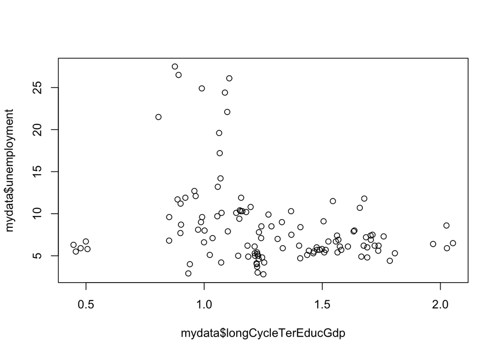

```r
plot(y=mydata$unemployment, x=mydata$longCycleTerEducGdp)
abline(modelLongCycleEducF)
```

```r
#I tried to put the line of the model through but it did not work as it used only first 2 of three regression coefficients (since can't plot in 3D)
```

```r
#plot(y=modelLongCycleEducF$residuals, x=mydata$longCycleTerEducGdp)

#I cannot plot the residuals either because their are too many dimensions
```

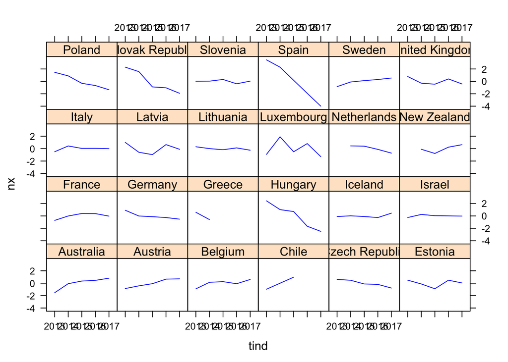

```r
plot(modelLongCycleEducF$residuals)
```

see how it does in terms of accuracy measures (p-values and R2) with a quadratic transformation for instance.

Model with long cycle tertiary education expenditure quadratic effect

```r
library(plm)
modelLongCycleEducQuadF <- plm(unemployment ~  avRatio + adultEducTer + longCycleTerEducGdp + I(longCycleTerEducGdp)^2, data = mydata, index = c("country", "year"), model = "within")


#need fixed
summary(modelLongCycleEducQuadF)
```

```
## Oneway (individual) effect Within Model
##
## Call:
## plm(formula = unemployment ~ avRatio + adultEducTer + longCycleTerEducGdp +
##     I(longCycleTerEducGdp)^2, data = mydata, model = "within",
##     index = c("country", "year"))
##
## Unbalanced Panel: n = 24, T = 2-5, N = 112
##
## Residuals:
##        Min.     1st Qu.      Median     3rd Qu.        Max.
## -3.9970e+00 -4.3449e-01  8.4259e-05  4.4955e-01  3.4684e+00
##
## Coefficients: (1 dropped because of singularities)
##                      Estimate Std. Error t-value Pr(>|t|)
## avRatio              0.039983   0.112240  0.3562  0.72255
## adultEducTer        -0.510615   0.078836 -6.4769 5.79e-09 ***
## longCycleTerEducGdp  2.410667   1.033597  2.3323  0.02205 *
## ---
## Signif. codes:  0 '***' 0.001 '**' 0.01 '*' 0.05 '.' 0.1 ' ' 1
##
## Total Sum of Squares:    188.01
## Residual Sum of Squares: 100.99
## R-Squared:      0.46284
## Adj. R-Squared: 0.29853
## F-statistic: 24.4132 on 3 and 85 DF, p-value: 1.7308e-11
```

## Nearly Normal Residuals

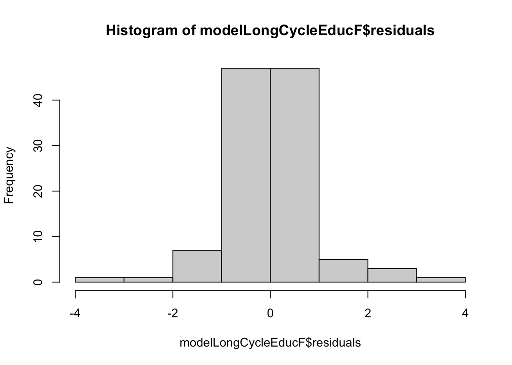

```r
hist(modelLongCycleEducF$residuals)
```

Looking at the histogram, the residuals do not seem skewed, however we can test to confirm this

```r
library(e1071)
skewness(modelLongCycleEducF$residuals)
```

```
## [1] -0.1391781
```

```r
2*sqrt(6/length(modelLongCycleEducF$residuals))
```

```
## [1] 0.46291
```

since our residuals g_1 is smaller than 2*sqrt(6/n), the residuals are not skewed.

From this, we can say that the residuals are not skewed, which strengthens model validity.

## Constant Variability

```r
library(lmtest)
bptest(unemployment ~ avRatio + adultEducTer + longCycleTerEducGdp + factor(country), data = mydata, studentize = F)
```

```
##
##  Breusch-Pagan test
##
## data:  unemployment ~ avRatio + adultEducTer + longCycleTerEducGdp +     factor(country)
## BP = 182.21, df = 26, p-value < 2.2e-16
```

it is called the Breusch-Pagan test (like the F-test) for H0 = homoskedasticity. Hence, if p-value is below 5%, then heteroskedasticity.

There is therefore heteroskedasticity since p-value < 2.2e-16 < 0.05

```r
coeftest(modelLongCycleEducF, vcovHC(modelLongCycleEducF, method = "arellano"))
```

```
##
## t test of coefficients:
##
##                      Estimate Std. Error t value  Pr(>|t|)
## avRatio              0.039983   0.089783  0.4453  0.657214
## adultEducTer        -0.510615   0.119826 -4.2613 5.231e-05 ***
## longCycleTerEducGdp  2.410667   0.840914  2.8667  0.005227 **
## ---
## Signif. codes:  0 '***' 0.001 '**' 0.01 '*' 0.05 '.' 0.1 ' ' 1
```

Since we have heteroskedasticity, a way to get the “robust” coefficients once you run the plm() function is the coefficient test. This gives us a “robust” coefficient of 2.410667 that is significant at a 0.01 level